# Sensitivity

Valerie Odeh

12/5/2022

# Create Synthetic Data with multiple covariates

```r
#Covariates, Running variable and outcome variable
set.seed(2020)
n=1000
d <- 4 #to use as treatment effect in Y
X <- array(rnorm(2*n),dim=c(n,2)) #two covariates
R <- X[,1] + X[,2] + rnorm(n) #Risk
A <- ifelse(R>=0, 1, 0) #assignment, cutoff=0
Y <-X[,1]+X[,2]+d*A+rnorm(n) #outcome
```

# Window selection

```
##
##
## Window selection for RD under local randomization
##
## Number of obs     =          1000
## Order of poly     =             0
## Kernel type       =       uniform
## Reps              =           500
## Testing method    =     rdrandinf
## Balance test      =     diffmeans
##
## Cutoff c =    0.000   Left of c  Right of c
##       Number of obs         533         467
##      1st percentile           5           5
##      5th percentile          26          23
##     10th percentile          53          47
##     20th percentile         107          94
##
## ================================================================================
##       Window          p-value        Var. name    Bin.test      Obs<c     Obs>=c
## ================================================================================
##   -0.0500   0.0500      0.336              X2       0.845         14         12
##   -0.1750   0.1750      0.066              X2       0.348         51         41
##   -0.3000   0.3000      0.016              X2       0.048         80         56
##   -0.4250   0.4250      0.000              X2       0.170        106         86
##   -0.5500   0.5500      0.000              X2       0.209        137        116
##   -0.6750   0.6750      0.000              X2       0.129        160        133
##   -0.8000   0.8000      0.000              X2       0.175        183        157
##   -0.9250   0.9250      0.000              X2       0.143        211        181
##   -1.0500   1.0500      0.000              X2       0.201        237        209
##   -1.1750   1.1750      0.000              X2       0.137        263        229
## ================================================================================
## Recommended window is [-0.05;0.05] with 26 observations (14 below, 12 above).
```

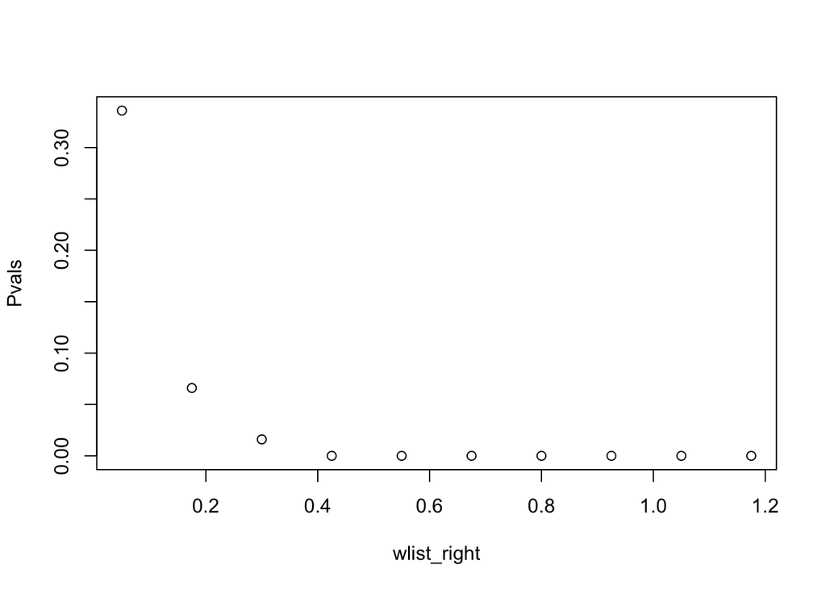

```r
###############################################################################
## rdwinselect
###############################################################################

window <- rdwinselect(R,X,wmin=.05,wstep=.125,reps=500, plot = TRUE)
```

# Test of no effect and ATE estimation

```r
###############################################################################
## rdrandinf
###############################################################################

# Randomization inference using recommended window window$w_left=-0.05, window$w_right=0.05

localrand <- rdrandinf(Y,R,wl=window$w_left,wr=window$w_right, covariates = X)
```

```
##
## Selected window = [-0.05;0.05]
##
## Running randomization-based test...
## Randomization-based test complete.
##
##
## Number of obs     =          1000
## Order of poly     =             0
## Kernel type       =       uniform
## Reps              =          1000
## Window            =   set by user
## H0:          tau  =         0.000
## Randomization     = fixed margins
##
## Cutoff c =    0.000   Left of c  Right of c
##       Number of obs         533         467
##  Eff. number of obs          14          12
##     Mean of outcome       0.291       3.969
##     S.d. of outcome       1.461       1.439
##              Window      -0.050       0.050
##
## ================================================================================
##                                   Finite sample            Large sample
##                                ------------------  -----------------------------
##           Statistic          T        P>|T|        P>|T|    Power vs d =   0.730
## ================================================================================
##      Diff. in means      3.678        0.000        0.000                   0.249
## ================================================================================
```

Results from the main panel below show the randomization test results using the difference in means statistic. We can see that the randomization test rejects the sharp null of no treatment effect at one percent significance level. Also, the observed value of the difference in means statistic has the appealing feature that it provides a point estimate of the average treatment effect (ATE) without imposing any restrictions on how the treatment effect varies across units.Moreover, one can easilyshow that this statistic is unbiased for the ATE when the treatment assignment follows a fixed-margin randomization scheme or Bernoulli trials. Therefore, from the above results, the ATE inside the window is 3.6779299 after adjusting for baseline covariates, which makes sense given that the parameter used to influence the treatment in the synthetic data was $d=4$.

# Sensitivity Analysis: Sensitivity to model specification and window length

```r
###############################################################################
## rdsensitivity
###############################################################################

sensitivity1 <- rdsensitivity(Y,R,wlist=seq(.05,1,by=.125),tlist=seq(0,8,by=1),ci=c(window$w_left,window$w_right) )
```

```
##
## Running sensitivity analysis...
## Sensitivity analysis complete.
```

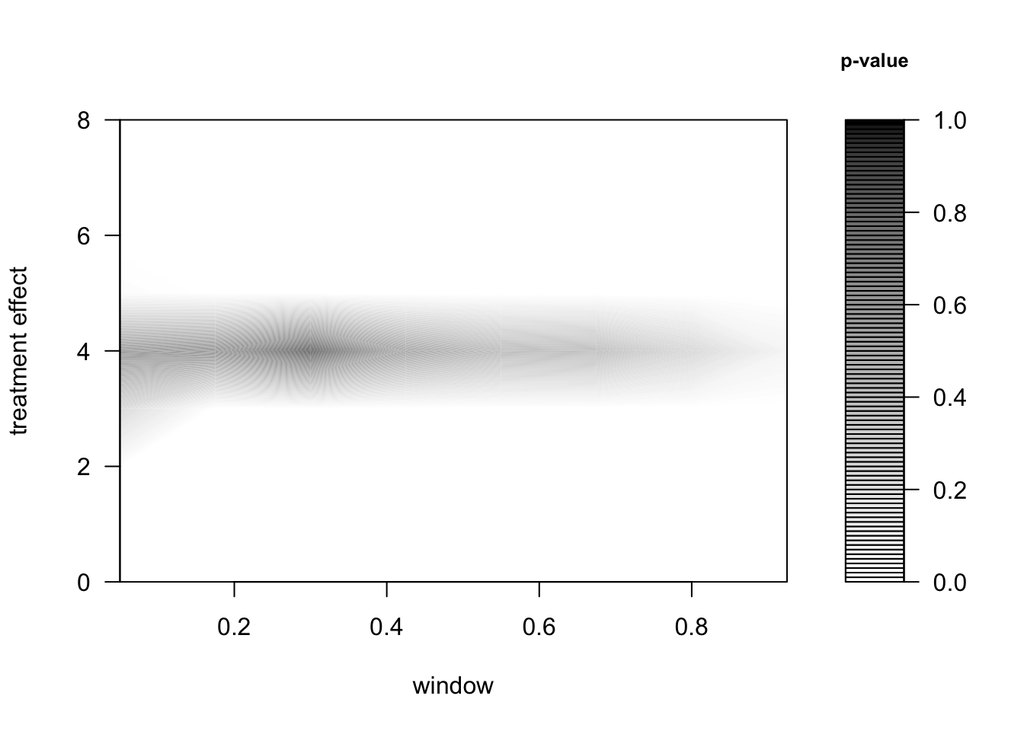

```r
sensitivity1$ci
```

```
##      [,1] [,2]
## [1,]    3    4
```

# Sensitivity Analysis: Sensitivity to unmeasured confounding

```r
sensitivity2 <- rdrbounds(Y,R,wlist=c(.05,.175,0.3),reps=1000)
```

```
##
## Calculating randomization p-value...
##
## Bernoulli p-value (w = 0.05) = 0
## Bernoulli p-value (w = 0.175) = 0
## Bernoulli p-value (w = 0.3) = 0
##
## Running sensitivity analysis...
##
## Sensitivity analysis complete.
```

```r
sensitivity2
```

```
## $gamma
## [1] 0.4054651 0.6931472 0.9162907 1.0986123
##
## $expgamma
## [1] 1.5 2.0 2.5 3.0
##
## $wlist
## [1] 0.050 0.175 0.300
##
## $p.values
## [1] 0 0 0
##
## $lower.bound
##      [,1] [,2] [,3]
## [1,]    0    0    0
## [2,]    0    0    0
## [3,]    0    0    0
## [4,]    0    0    0
##
## $upper.bound
##       [,1] [,2] [,3]
## [1,] 0.000    0    0
## [2,] 0.002    0    0
## [3,] 0.006    0    0
## [4,] 0.011    0    0
```

The second type of sensitivity analysis is performed with rdrbounds, which calculates Rosenbaum bounds [Rosenbaum, 2002]. This command calculates upper and lower bounds for the randomization p-value under Bernoulli trials for a range of values of a parameter exp(gamma) that captures the strength with which an unobservable binary variable $U_i$ affects the probability of selection into treatment.

The output from rdrbounds is divided in several parts. The first one shows the randomization p-value based on Bernoulli trials for each window. The matrices sensitivity2 lower.bound and sensitivity2 upper.bound present the lower and upper bounds for the p-values for different values of gamma and windows. The wider the distance between the lower and upper bounds, the more sensitive the inference to deviations from a randomized experiment.

There are two directions in which one can look at the lower and upper bound matrices. Fixing a column (that is, for a fixed window length) and moving across rows, the table indicates how inference is affected by different degrees of departure from a randomized experiment. This is the type of sensitivity analysis described in Rosenbaum (2002). On the other hand, fixing a row (that is, for a fixed value of gamma) and moving across columns, the matrix shows how sensitive the upper and lower bounds for the p-value are to the choice of the window.

For the window length selected using rdwinselect, [−0.05; 0.05], the p-values look fairly robust to misspecification of the selection mechanism: distance between the lower and upper bounds is not significantly big.